# Technical Assessment

Huiyu (Joyce) Hu

5/5/2018

```r
##load any librarys you may need.  tidyverse has already been loaded here for you
libraries <- c("tidyverse", "PK")
for (l in libraries) {
  suppressPackageStartupMessages(library(l, character.only = TRUE))
}
```

## Instructions

This is an assessment project to be completed by prospective candidates looking to apply to the Biometrics Department at Denali Therapeutics. The assessment is intended to take between 30-60 minutes to complete and is aimed at assessing required technical skills. Please feel free to include more comprehensive or alternative approaches as you deem fit. Completed report should be in html format. Please create a **new github repository** to share your work with us.

- Please find the code at https://github.com/huiyuhu/Clinical_Data_Scientist_Intern

## Data

Start by loading the dataset Theoph. This is data relating to a pharmacokinetics experiment of the anti-asthmatic drug theophylline.

```r
data(Theoph)
head(Theoph)
```

```
## Grouped Data: conc ~ Time | Subject
##   Subject   Wt Dose Time  conc
## 1       1 79.6 4.02 0.00  0.74
## 2       1 79.6 4.02 0.25  2.84
## 3       1 79.6 4.02 0.57  6.57
## 4       1 79.6 4.02 1.12 10.50
## 5       1 79.6 4.02 2.02  9.66
## 6       1 79.6 4.02 3.82  8.58
```

To add a bit more complexity, we will introduce a hypothetical demographics dataset characterizing the subjects.

```r
## data cleanup and preprocessing
dm <- read.csv("dm.csv")
dm <- as.data.frame(dm)
dm1 <- dm %>%
  mutate_if(is.factor, as.character) %>%
  # Step 1: For sex, only select the first character
  mutate(SEX, Sex = str_sub(SEX, start = 1, end = 1)) %>%
  select(-SEX) %>%
  # Step 2: Age data is noisy. The goal is transform all types of age data to "years"
  mutate(num = parse_number(Age)) %>%
  # Step 2.1: Transform months and weeks to years
  mutate(is.month = str_detect(Age, regex('month', ignore_case = T))) %>%
  mutate(is.week = str_detect(Age, regex('week', ignore_case = T)))
dm_clean <- dm1 %>%
  mutate(age = case_when(is.month ~ (num/12),
                      is.week ~ (num/52),
                      !is.month & !is.week ~ num)) %>%
  select(-num, -is.month, -is.week, -Age) %>%
  mutate(age = round(age, 1)) %>%
  # Step 2.2: Filter out abnormal/incorrect age range
  filter(age > 0 & age <= 150)

# Join the two datasets together
Theoph$Subject <- as.integer(Theoph$Subject)
th_dm <- dm_clean %>%
  inner_join(Theoph, by = c("SUBJECT" = "Subject"))
head(th_dm)
```

```
##   SUBJECT Sex  age Wt Dose Time conc
## 1       1   M 32.8 80    4 0.00 0.00
## 2       1   M 32.8 80    4 0.27 1.29
## 3       1   M 32.8 80    4 0.58 3.08
## 4       1   M 32.8 80    4 1.15 6.44
## 5       1   M 32.8 80    4 2.03 6.32
## 6       1   M 32.8 80    4 3.57 5.53
```

```r
write_rds(th_dm, "Theoph_shiny/th_dm.rds")
```

**Please characterize and provide a summary of the data stratefied by gender.**

*Hint: Don’t forget to also include characterization of age, weight and peak concentrations.*

```r
# characterization and summary data
# Summary 1
th_dm %>%
  group_by(Sex) %>%
  summarise(age_mean = mean(age), age_sd = sd(age),
            wt_mean = mean(Wt), wt_sd = sd(Wt),
            dose_mean = mean(Dose), dose_sd = sd(Dose),
            con_peak = max(conc))
```

```
## # A tibble: 2 x 8
##   Sex   age_mean age_sd wt_mean wt_sd dose_mean dose_sd con_peak
##   <chr>    <dbl>  <dbl>   <dbl> <dbl>     <dbl>   <dbl>    <dbl>
## 1 F         47.2   9.51    73.9  8.81      4.27   0.725     10.5
## 2 M         46.2   9.49    65.5  8.31      4.96   0.612     11.4
```

```r
# Summary 2
th_dm %>%
  select(SUBJECT, age, Wt, Dose, Sex) %>%
  group_by(SUBJECT) %>%
  distinct(age, Wt, Dose, Sex) %>%
  group_by(Sex) %>%
  summarise(age_mean = mean(age), age_sd = sd(age),
            wt_mean = mean(Wt), wt_sd = sd(Wt),
            dose_mean = mean(Dose), dose_sd = sd(Dose))
```

```
## # A tibble: 2 x 7
##   Sex   age_mean age_sd wt_mean wt_sd dose_mean dose_sd
##   <chr>    <dbl>  <dbl>   <dbl> <dbl>     <dbl>   <dbl>
## 1 F         47.2   10.5    73.9  9.76      4.27   0.803
## 2 M         46.2   10.3    65.5  9.04      4.96   0.665
```

- The table 1 above showed the data chracterization of age, weight, dose, and peak concentration by using the joint data, but since the age, weight and dose were repeated 11 times, the standard deviations were underestimated.
- To make the result more precise, table 2 showed the result by using data without repeatation.

## Visualization

You need to convey the data in a presentation. Please generate figures to convey the data we have captured. Pay particular attention to showing concentration change over time as this is a PK experiment. Please take time to make the figure as informative as possible. Feel free to use more than one figure if needed but bear in mind that this is a presentation so fewer figures to convey the information is a plus. Bonus points for interactivity!

**Method 1: Use ggplot to visualize the PK experiment.**

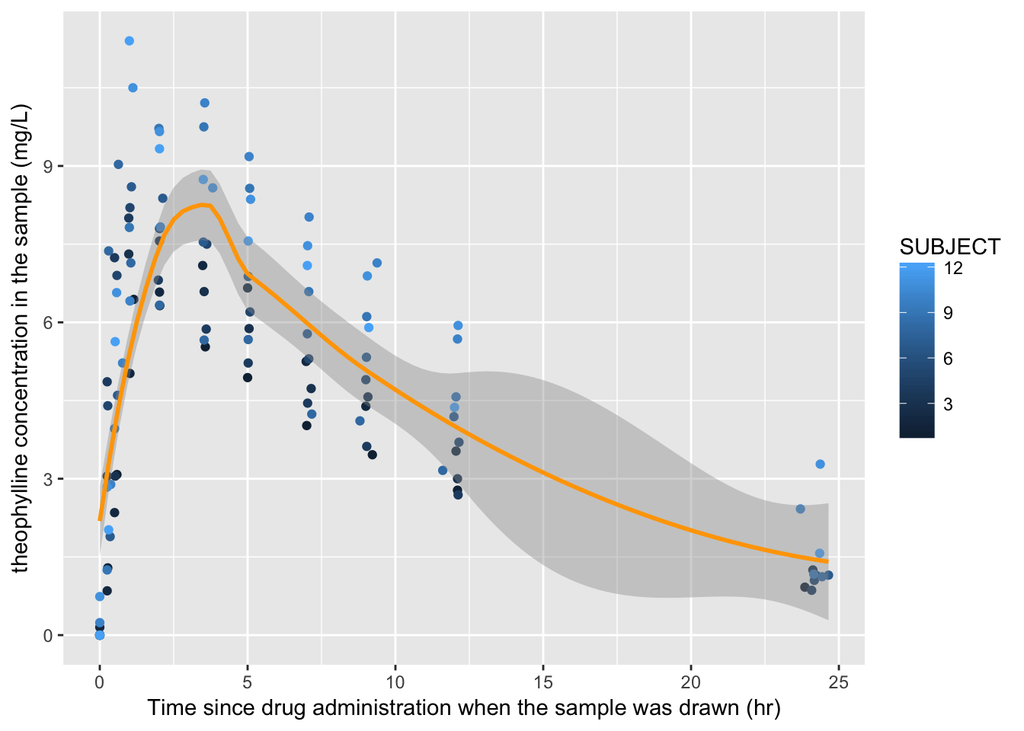

```r
##input visualization code here
th_dm %>%
  ggplot(aes(Time, conc)) +
  geom_point(aes(group = SUBJECT, colour = SUBJECT)) +
  geom_smooth(color = "orange", method = "loess") +
  labs(x = "Time since drug administration when the sample was drawn (hr)",
       y = "theophylline concentration in the sample (mg/L)")
```

- Overall pattern: Concentration increase with the time at first then start decrease after ~4 hours (peak).

**Method 2: Use Shiny App to visualize the interactive plot.**

The link: https://huiyuhu.shinyapps.io/pkexp_shiny/

- `Subject Overall information` showed that the all points and loess line. Click the point can see the the detail information correspondingly.
- `Each Subject information` showed that the plot of each subject and the table of each subject.

## Analysis

Next, we would like to estimate the PK property, area under the curve (AUC), for the drug based on the available data. Please provide an **estimate** along with **associated variability**. Explain in detail any imputations or assumptions that were made.

```r
##input code for estimating AUC here.

th_dm <- as.data.frame(th_dm)
#Method 1: use mean of conc
con_m1 <- matrix(unlist(th_dm$conc), ncol = 11, byrow = TRUE)
time_m1 <- matrix(unlist(th_dm$Time), ncol = 11, byrow = TRUE)
con1 <- as.vector(colMeans(con_m1))
time1 <- as.vector(colMeans(time_m1))
auc(conc = con1, time = time1,
    method=c("t"), design=c("complete"))
```

```
## Estimation for a complete data design
##
##              Estimate SE 95% t-CI
## AUC to tlast   104.87 NA  (NA;NA)
```

```r
#Method 2: use loess predcted value
smooth_vals = predict(loess(th_dm$conc ~ th_dm$Time), th_dm, normalize = T)
con_m2 <- matrix(unlist(smooth_vals), ncol = 11, byrow = TRUE)
con2 <- as.vector(colMeans(con_m2))
auc(conc = con2, time = time1,
    method=c("t"), design=c("complete"))
```

```
## Estimation for a complete data design
##
##              Estimate SE 95% t-CI
## AUC to tlast   104.40 NA  (NA;NA)
```

```r
# Method 3: With variance
# Repeat the dataset twice to make the auc computation successful
result <- auc(conc = rep(th_dm$conc, 2), time = rep(th_dm$Time, 2), method = c("z", "t"), design = "ssd")
print(result)
```

```
## Estimation for a serial sampling design
##
##              Estimate    SE        95% t-CI
## AUC to tlast   108.28 0.327 (107.40;109.17)
##
##              Estimate    SE        95% z-CI
## AUC to tlast   108.28 0.327 (107.64;108.93)
```

```r
summary(result)
```

```
## Confidence intervals for a serial sampling design
##
##  Point estimate
##
##                   est        se
## AUC to tlast 108.2852 0.3270274
##
##  Confidence Intervals
##
##                                                   lower    upper
## 95% CI using a t distribution for AUC to tlast 107.4043 109.1660
## 95% CI using a z distribution for AUC to tlast 107.6442 108.9261
##
## degrees of freedom: 4.336481
```

- Method 1: Calculate the mean of each time spot to calculate the AUC. **Result: 104.87**
- Method 2: Get the loess line predicted value to calculate the AUC. **Result: 104.40**
- Method 3: Since the auc function needs at least 2 data at each time point, the data was repeated twice, which could underestimate the variance. This repeat could be avoided when the dataset is larger.